# Aedes aegypti Brazil - Local adaptation analysis - outFlank

Luciano V Cosme

2023-12-20

Analysis code

## 1. R libraries and software

```r
library(tidyverse)
library(colorout)
library(here)
library(ggplot2)
library(scales)
library(reticulate)
library(extrafont)
library(forcats)
library(ggrepel)
library(ggtext)
library(rgdal)
library(stats)
library(geosphere)
library(vcfR)
library(OutFLANK)
```

## 2. outFLANK

This tool does not directly account for population structure. It instead looks for loci that show a higher Fst than the neutral expectation, under a model of hierarchical population structure. The method is robust to hierarchical population structure and a range of demographic histories.

Check the documentation https://htmlpreview.github.io/?https://github.com/whitlock/OutFLANK/blob/master/inst/doc/OutFLANKAnalysis.html

“OutFLANK is an R package that implements the method developed by Whitlock and Lotterhos (2015) to use likelihood on a trimmed distribution of FST values to infer the distribution of FST for neutral markers. This distribution is then used to assign q-values to each locus to detect outliers that may be due to spatially heterogeneous selection.”

```r
library(vcfR)
library(OutFLANK)
browseVignettes("OutFLANK")
```

```
## starting httpd help server ... done
```

### 2.1 OutFLANK analysis with quasi-independent set of SNPs

Use the list of intergenic snps to create a vcf

```bash
plink2 \
--bfile output/populations/snps_sets/snpeff \
--export vcf \
--make-bed \
--extract output/snpeff/intergenic_SNPs.txt \
--maf 0.05 \
--geno 0.2 \
--out output/local_adaptation/outflank/intergenic \
--silent;
grep 'samples\|variants\|remaining' output/local_adaptation/outflank/intergenic.log
```

```
## 374 samples (0 females, 0 males, 374 ambiguous; 374 founders) loaded from
## 13082 variants loaded from output/populations/snps_sets/snpeff.bim.
## --extract: 3366 variants remaining.
## --geno: 0 variants removed due to missing genotype data.
## 0 variants removed due to allele frequency threshold(s)
## 3366 variants remaining after main filters.
```

We need to import the data

```r
# Read your vcf file
vcf <- read.vcfR(here("output","local_adaptation","outflank","intergenic.vcf"))
```

```
## Scanning file to determine attributes.
## File attributes:
##   meta lines: 8
##   header_line: 9
##   variant count: 3366
##   column count: 383
##
Meta line 8 read in.
## All meta lines processed.
## gt matrix initialized.
## Character matrix gt created.
##   Character matrix gt rows: 3366
##   Character matrix gt cols: 383
##   skip: 0
##   nrows: 3366
##   row_num: 0
##
Processed variant 1000
Processed variant 2000
Processed variant 3000
Processed variant: 3366
## All variants processed
```

```r
# Extract genotypes
geno <- vcfR::extract.gt(vcf)

# Extract locus names (positions)
locusNames <- vcfR::getPOS(vcf)

# Samples
sampleNames <- colnames(geno)

# Extract population names by splitting the sample names
# If your sample names contain population information.
popNames <- sapply(strsplit(sampleNames, "_"), "[", 1)

# Initialize new matrix for transformed genotypes
G <- matrix(NA, nrow = nrow(geno), ncol = ncol(geno))

# Recode genotypes
G[geno %in% c("0/0", "0|0")] <- 0
G[geno %in% c("0/1", "1/0", "1|0", "0|1")] <- 1
G[geno %in% c("1/1", "1|1")] <- 2

# Replace NA with 9 for missing data
G <- replace(G, is.na(G), 9)

# Check the counts of each genotype
table(as.vector(G))
```

```
##
##      0      1      2      9
## 738679 357940 130773  31492
```

```r
# Extract SNP names
snpNames <- vcfR::getID(vcf)

# Calculate FST with SNP names
my_fst <- MakeDiploidFSTMat(t(G), locusNames = snpNames, popNames = popNames)
```

```
## Calculating FSTs, may take a few minutes...
```

```r
head(my_fst)
```

```
##     LocusName        He       FST         T1        T2 FSTNoCorr   T1NoCorr
## 1 AX-93255731 0.4695822 0.1731406 0.04091124 0.2362891 0.2110440 0.04986889
## 2 AX-93255729 0.4723557 0.1632783 0.03879921 0.2376263 0.2028279 0.04819881
## 3 AX-93255719 0.2299076 0.1140357 0.01317329 0.1155190 0.1628700 0.01881545
## 4 AX-93257574 0.4656696 0.1558255 0.03648927 0.2341675 0.1895118 0.04437867
## 5 AX-93253527 0.2222957 0.1269634 0.01418543 0.1117285 0.1728002 0.01930754
## 6 AX-93252859 0.2551876 0.1776590 0.02281926 0.1284442 0.2203008 0.02829735
##    T2NoCorr meanAlleleFreq
## 1 0.2362962      0.6233244
## 2 0.2376340      0.6175676
## 3 0.1155243      0.8674863
## 4 0.2341737      0.6310160
## 5 0.1117333      0.8726287
## 6 0.1284487      0.8498660
```

We can select the SNPs with low FST to use as neutral SNPs

```r
my_fst |>
  filter(FST<=0.2) |>
  dplyr::select(LocusName) -> neutral_snps

length(neutral_snps$LocusName)
```

```
## [1] 3219
```

```r
write.table(
  neutral_snps$LocusName,
  file = here("output", "local_adaptation", "outflank","neutral_SNPs.txt"),
  row.names = FALSE,
  quote = FALSE,
  col.names = FALSE,
  sep = "\n"
)
```

Create a vcf

```bash
plink2 \
--bfile output/local_adaptation/outflank/intergenic \
--export vcf-4.2 \
--extract output/local_adaptation/outflank/neutral_SNPs.txt \
--out output/local_adaptation/outflank/neutral \
--silent;
grep "samples\|variants" output/local_adaptation/outflank/neutral.log
```

```
## 374 samples (0 females, 0 males, 374 ambiguous; 374 founders) loaded from
## 3366 variants loaded from output/local_adaptation/outflank/intergenic.bim.
## --extract: 3219 variants remaining.
## 3219 variants remaining after main filters.
```

Import the data.

```r
# Read your vcf file
vcf <- read.vcfR(here("output","local_adaptation","outflank","neutral.vcf"))
```

```
## Scanning file to determine attributes.
## File attributes:
##   meta lines: 8
##   header_line: 9
##   variant count: 3219
##   column count: 383
##
Meta line 8 read in.
## All meta lines processed.
## gt matrix initialized.
## Character matrix gt created.
##   Character matrix gt rows: 3219
##   Character matrix gt cols: 383
##   skip: 0
##   nrows: 3219
##   row_num: 0
##
Processed variant 1000
Processed variant 2000
Processed variant 3000
Processed variant: 3219
## All variants processed
```

```r
# Extract genotypes
geno <- vcfR::extract.gt(vcf)

# Extract locus names (positions)
locusNames <- vcfR::getPOS(vcf)

# Samples
sampleNames <- colnames(geno)

# Extract population names by splitting the sample names
# If your sample names contain population information.
popNames <- sapply(strsplit(sampleNames, "_"), "[", 1)

# Initialize new matrix for transformed genotypes
G <- matrix(NA, nrow = nrow(geno), ncol = ncol(geno))

# Recode genotypes
G[geno %in% c("0/0", "0|0")] <- 0
G[geno %in% c("0/1", "1/0", "1|0", "0|1")] <- 1
G[geno %in% c("1/1", "1|1")] <- 2

# Replace NA with 9 for missing data
G <- replace(G, is.na(G), 9)

# Check the counts of each genotype
table(as.vector(G))
```

```
##
##      0      1      2      9
## 703474 347503 123189  29740
```

```r
# Extract SNP names
snpNames <- vcfR::getID(vcf)

# Calculate FST with SNP names
my_fst <- MakeDiploidFSTMat(t(G), locusNames = snpNames, popNames = popNames)
```

```
## Calculating FSTs, may take a few minutes...
```

```r
head(my_fst)
```

```
##     LocusName        He       FST         T1        T2 FSTNoCorr   T1NoCorr
## 1 AX-93255731 0.4695822 0.1731406 0.04091124 0.2362891 0.2110440 0.04986889
## 2 AX-93255729 0.4723557 0.1632783 0.03879921 0.2376263 0.2028279 0.04819881
## 3 AX-93255719 0.2299076 0.1140357 0.01317329 0.1155190 0.1628700 0.01881545
## 4 AX-93257574 0.4656696 0.1558255 0.03648927 0.2341675 0.1895118 0.04437867
## 5 AX-93253527 0.2222957 0.1269634 0.01418543 0.1117285 0.1728002 0.01930754
## 6 AX-93252859 0.2551876 0.1776590 0.02281926 0.1284442 0.2203008 0.02829735
##    T2NoCorr meanAlleleFreq
## 1 0.2362962      0.6233244
## 2 0.2376340      0.6175676
## 3 0.1155243      0.8674863
## 4 0.2341737      0.6310160
## 5 0.1117333      0.8726287
## 6 0.1284487      0.8498660
```

Data prep: decide which SNPs to use for calibrating the null distribution of Fst

```r
# Run OutFLANK to estimate the neutral FST distribution
out_trim <- OutFLANK(FstDataFrame = my_fst, Hmin = 0.1, NumberOfSamples = 10, qthreshold = 0.05)
str(out_trim)
```

```
## List of 6
##  $ FSTbar               : num 0.0759
##  $ FSTNoCorrbar         : num 0.122
##  $ dfInferred           : num 13.5
##  $ numberLowFstOutliers : int 0
##  $ numberHighFstOutliers: int 0
##  $ results              :'data.frame':   3219 obs. of  15 variables:
##   ..$ LocusName       : chr [1:3219] "AX-93255731" "AX-93255729" "AX-93255719" "AX-93257574" ...
##   ..$ He              : num [1:3219] 0.47 0.472 0.23 0.466 0.222 ...
##   ..$ FST             : num [1:3219] 0.173 0.163 0.114 0.156 0.127 ...
##   ..$ T1              : num [1:3219] 0.0409 0.0388 0.0132 0.0365 0.0142 ...
##   ..$ T2              : num [1:3219] 0.236 0.238 0.116 0.234 0.112 ...
##   ..$ FSTNoCorr       : num [1:3219] 0.211 0.203 0.163 0.19 0.173 ...
##   ..$ T1NoCorr        : num [1:3219] 0.0499 0.0482 0.0188 0.0444 0.0193 ...
##   ..$ T2NoCorr        : num [1:3219] 0.236 0.238 0.116 0.234 0.112 ...
##   ..$ meanAlleleFreq  : num [1:3219] 0.623 0.618 0.867 0.631 0.873 ...
##   ..$ indexOrder      : int [1:3219] 1 2 3 4 5 6 7 8 9 10 ...
##   ..$ GoodH           : chr [1:3219] "goodH" "goodH" "goodH" "goodH" ...
##   ..$ qvalues         : num [1:3219] 0.767 0.767 0.767 0.767 0.767 ...
##   ..$ pvalues         : num [1:3219] 0.0918 0.1181 0.3619 0.1752 0.2791 ...
##   ..$ pvaluesRightTail: num [1:3219] 0.0459 0.0591 0.181 0.0876 0.1395 ...
##   ..$ OutlierFlag     : logi [1:3219] FALSE FALSE FALSE FALSE FALSE FALSE ...
```

Check the fit and make sure it looks good, especially in the right tail:

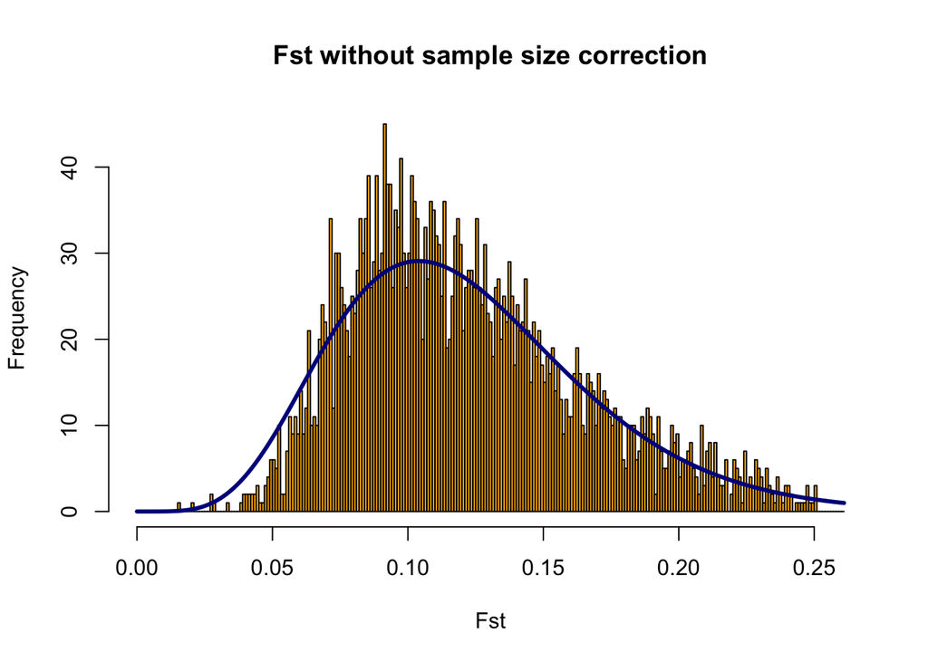

```r
OutFLANKResultsPlotter(
  out_trim,
  withOutliers = TRUE,
  NoCorr = TRUE,
  Hmin = 0.1,
  binwidth = 0.001,
  Zoom = FALSE,
  RightZoomFraction = 0.05,
  titletext = NULL
)
```

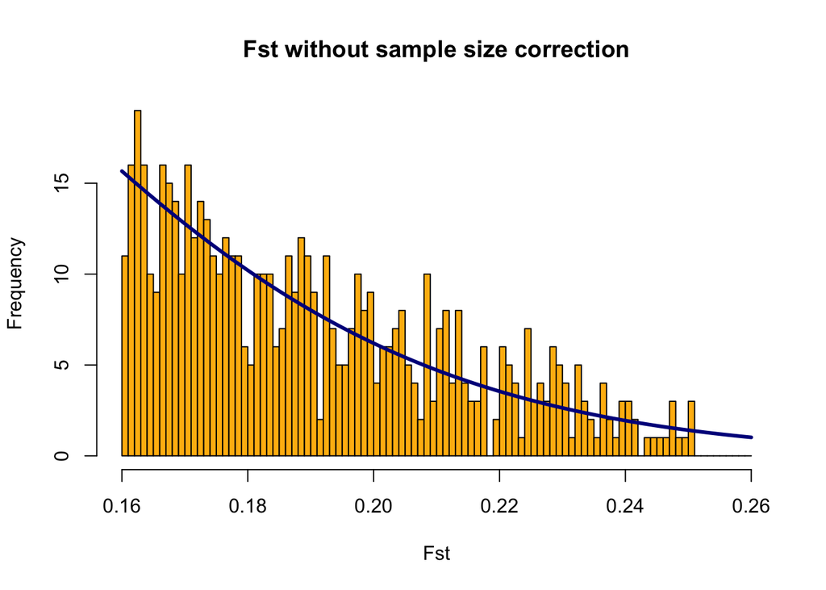

```r
## Zoom in on right tail
OutFLANKResultsPlotter(
  out_trim ,
  withOutliers = TRUE,
  NoCorr = TRUE,
  Hmin = 0.1,
  binwidth = 0.001,
  Zoom =
    TRUE,
  RightZoomFraction = 0.15,
  titletext = NULL
)
```

Also check the P-value histogram: Here, we plot the “right-tailed” P-values, which means that outliers in the right tail of the FST distribution will have a P-value near zero. Because we ran the algorithm on a trimmed set of SNPs, this will remove some of the signal around selected sites. So we expect this histogram to be flat and maybe have a bump near 0 for selected sites. This histogram looks pretty good.

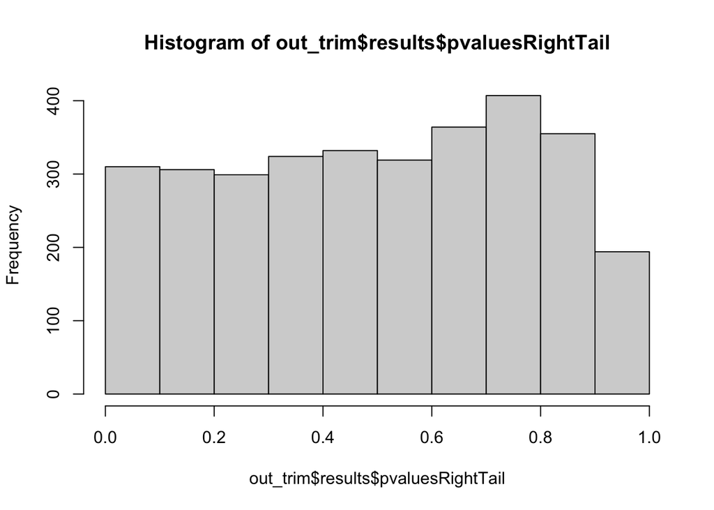

```r
hist(out_trim$results$pvaluesRightTail)
```

### 2.2 Using estimated neutral mean FST and df to calculate P-values for all loci

Now that we’ve estimated neutral mean FST and df to a quasi-independent set of SNPs, we can go and calculate P-values and q-values for all the loci in our dataset before prunning.

Note that it is important to run this code with the uncorrected FSTs (FSTNoCorr) and the uncorrected mean FST (FSTNoCorrbar).

Now we can use the entire data set to estimate the fst

Create a vcf - ld pruned data

```bash
plink2 \
--bfile output/populations/snps_sets/brazil_2018 \
--export vcf \
--make-bed \
--out output/local_adaptation/outflank/brazil \
--silent;
grep "samples\|variants" output/local_adaptation/outflank/brazil.log
```

```
## 374 samples (0 females, 0 males, 374 ambiguous; 374 founders) loaded from
## 8345 variants loaded from output/populations/snps_sets/brazil_2018.bim.
```

Import the data

```r
library(vcfR)
library(OutFLANK)
# Read your vcf file
vcf2 <- read.vcfR(here("output","local_adaptation","outflank","brazil.vcf"))
```

```
## Scanning file to determine attributes.
## File attributes:
##   meta lines: 8
##   header_line: 9
##   variant count: 8345
##   column count: 383
##
Meta line 8 read in.
## All meta lines processed.
## gt matrix initialized.
## Character matrix gt created.
##   Character matrix gt rows: 8345
##   Character matrix gt cols: 383
##   skip: 0
##   nrows: 8345
##   row_num: 0
##
Processed variant 1000
Processed variant 2000
Processed variant 3000
Processed variant 4000
Processed variant 5000
Processed variant 6000
Processed variant 7000
Processed variant 8000
Processed variant: 8345
## All variants processed
```

```r
# Extract genotypes
geno2 <- vcfR::extract.gt(vcf2)

# Extract locus names (positions)
locusNames2 <- vcfR::getPOS(vcf2)

# Samples
sampleNames2 <- colnames(geno2)

# Extract population names by splitting the sample names
# If your sample names contain population information.
popNames2 <- sapply(strsplit(sampleNames2, "_"), "[", 1)

# Initialize new matrix for transformed genotypes
H <- matrix(NA, nrow = nrow(geno2), ncol = ncol(geno2))

# Recode genotypes
H[geno2 %in% c("0/0", "0|0")] <- 0
H[geno2 %in% c("0/1", "1/0", "1|0", "0|1")] <- 1
H[geno2 %in% c("1/1", "1|1")] <- 2

# Replace NA with 9 for missing data
H <- replace(H, is.na(H), 9)

# Check the counts of each genotype
table(as.vector(H))
```

```
##
##       0       1       2       9
## 1771340  921909  357775   70006
```

```r
# Extract SNP names
snpNames <- vcfR::getID(vcf2)

# Use the option below for names if you want to make the plot without having to add the postion later on
locusNames2 <- vcfR::getPOS(vcf2)

# Calculate FST
my_fst2 <- MakeDiploidFSTMat(t(H), locusNames = locusNames2, popNames = popNames2)
```

```
## Calculating FSTs, may take a few minutes...
```

```r
my_fst3 <- MakeDiploidFSTMat(t(H), locusNames = snpNames, popNames = popNames2) # with SNP id instead of position
```

```
## Calculating FSTs, may take a few minutes...
```

```r
# Concatenate the SNP names and the SNP positions
locusNames3 <- paste(snpNames, locusNames2, sep = ".")

# Calculate FST with the combined names
my_fst4 <- MakeDiploidFSTMat(t(H), locusNames = locusNames3, popNames = popNames2)
```

```
## Calculating FSTs, may take a few minutes...
```

```r
# Check output
head(my_fst2)
```

```
##   LocusName        He        FST          T1         T2 FSTNoCorr    T1NoCorr
## 1     39205 0.4723557 0.16327827 0.038799209 0.23762629 0.2028279 0.048198811
## 2     61265 0.1414867 0.05981997 0.004244749 0.07095872 0.1016340 0.007212058
## 3    104497 0.4921037 0.15539670 0.038458082 0.24748326 0.1926697 0.047683909
## 4    122889 0.2299076 0.11403569 0.013173293 0.11551904 0.1628700 0.018815447
## 5    179618 0.1159846 0.07221864 0.004202705 0.05819419 0.1159196 0.006746100
## 6    183444 0.4961987 0.15844170 0.039550136 0.24961949 0.2023078 0.050501992
##     T2NoCorr meanAlleleFreq
## 1 0.23763404      0.6175676
## 2 0.07096111      0.9233871
## 3 0.24749046      0.5628342
## 4 0.11552434      0.8674863
## 5 0.05819639      0.9381868
## 6 0.24962951      0.5435967
```

```r
head(my_fst3)
```

```
##     LocusName        He        FST          T1         T2 FSTNoCorr    T1NoCorr
## 1 AX-93255729 0.4723557 0.16327827 0.038799209 0.23762629 0.2028279 0.048198811
## 2 AX-93255723 0.1414867 0.05981997 0.004244749 0.07095872 0.1016340 0.007212058
## 3 AX-93255722 0.4921037 0.15539670 0.038458082 0.24748326 0.1926697 0.047683909
## 4 AX-93255719 0.2299076 0.11403569 0.013173293 0.11551904 0.1628700 0.018815447
## 5 AX-93255712 0.1159846 0.07221864 0.004202705 0.05819419 0.1159196 0.006746100
## 6 AX-93255711 0.4961987 0.15844170 0.039550136 0.24961949 0.2023078 0.050501992
##     T2NoCorr meanAlleleFreq
## 1 0.23763404      0.6175676
## 2 0.07096111      0.9233871
## 3 0.24749046      0.5628342
## 4 0.11552434      0.8674863
## 5 0.05819639      0.9381868
## 6 0.24962951      0.5435967
```

```r
head(my_fst4)
```

```
##            LocusName        He        FST          T1         T2 FSTNoCorr
## 1  AX-93255729.39205 0.4723557 0.16327827 0.038799209 0.23762629 0.2028279
## 2  AX-93255723.61265 0.1414867 0.05981997 0.004244749 0.07095872 0.1016340
## 3 AX-93255722.104497 0.4921037 0.15539670 0.038458082 0.24748326 0.1926697
## 4 AX-93255719.122889 0.2299076 0.11403569 0.013173293 0.11551904 0.1628700
## 5 AX-93255712.179618 0.1159846 0.07221864 0.004202705 0.05819419 0.1159196
## 6 AX-93255711.183444 0.4961987 0.15844170 0.039550136 0.24961949 0.2023078
##      T1NoCorr   T2NoCorr meanAlleleFreq
## 1 0.048198811 0.23763404      0.6175676
## 2 0.007212058 0.07096111      0.9233871
## 3 0.047683909 0.24749046      0.5628342
## 4 0.018815447 0.11552434      0.8674863
## 5 0.006746100 0.05819639      0.9381868
## 6 0.050501992 0.24962951      0.5435967
```

Data checks: Heterozygosity vs. FST Here, you can see how some of the low H loci have high FST. These are all neutral loci in the simulation, and it is important to exclude them from the OutFLANK algorithm.

Note that it is important to run this code with the uncorrected FSTs (FSTNoCorr) and the uncorrected mean FST (FSTNoCorrbar).

```r
P1 <-
  pOutlierFinderChiSqNoCorr(
    my_fst4,
    Fstbar = out_trim$FSTNoCorrbar,
    dfInferred = out_trim$dfInferred,
    qthreshold = 0.05,
    Hmin = 0.1
  )
head(P1)
```

```
##            LocusName        He        FST          T1         T2 FSTNoCorr
## 1  AX-93255729.39205 0.4723557 0.16327827 0.038799209 0.23762629 0.2028279
## 2  AX-93255723.61265 0.1414867 0.05981997 0.004244749 0.07095872 0.1016340
## 3 AX-93255722.104497 0.4921037 0.15539670 0.038458082 0.24748326 0.1926697
## 4 AX-93255719.122889 0.2299076 0.11403569 0.013173293 0.11551904 0.1628700
## 5 AX-93255712.179618 0.1159846 0.07221864 0.004202705 0.05819419 0.1159196
## 6 AX-93255711.183444 0.4961987 0.15844170 0.039550136 0.24961949 0.2023078
##      T1NoCorr   T2NoCorr meanAlleleFreq   pvalues pvaluesRightTail   qvalues
## 1 0.048198811 0.23763404      0.6175676 0.1181242       0.05906211 0.4294304
## 2 0.007212058 0.07096111      0.9233871 0.7402845       0.62985777 0.7054922
## 3 0.047683909 0.24749046      0.5628342 0.1598273       0.07991365 0.4753043
## 4 0.018815447 0.11552434      0.8674863 0.3619231       0.18096157 0.6001828
## 5 0.006746100 0.05819639      0.9381868 0.9966303       0.50168484 0.7054922
## 6 0.050501992 0.24962951      0.5435967 0.1199988       0.05999940 0.4296386
##   OutlierFlag
## 1       FALSE
## 2       FALSE
## 3       FALSE
## 4       FALSE
## 5       FALSE
## 6       FALSE
```

```r
tail(P1)
```

```
##                  LocusName         He        FST           T1         T2
## 6813 AX-93229944.205810971 0.09623194 0.06886151 0.0033248036 0.04828247
## 6947 AX-93231633.217643154 0.09644256 0.09311330 0.0045093175 0.04842829
## 7340 AX-93241496.255363034 0.09644256 0.00946973 0.0004573752 0.04829866
## 7643 AX-93251412.294089035 0.09884112 0.10668802 0.0052963685 0.04964352
## 7816 AX-93217522.331733658 0.09500000 0.05842372 0.0027844021 0.04765876
## 7909 AX-93232113.345965163 0.09668725 0.05846197 0.0028344276 0.04848327
##       FSTNoCorr    T1NoCorr   T2NoCorr meanAlleleFreq pvalues pvaluesRightTail
## 6813 0.11468004 0.005537327 0.04828501      0.9493151      NA               NA
## 6947 0.14296595 0.006923865 0.04843017      0.9491979      NA               NA
## 7340 0.05425675 0.002620620 0.04830034      0.9491979      NA               NA
## 7643 0.14998016 0.007445794 0.04964519      0.9478610      NA               NA
## 7816 0.11161144 0.005319511 0.04766098      0.9500000      NA               NA
## 7909 0.09642871 0.004675320 0.04848473      0.9490617      NA               NA
##      qvalues OutlierFlag
## 6813      NA          NA
## 6947      NA          NA
## 7340      NA          NA
## 7643      NA          NA
## 7816      NA          NA
## 7909      NA          NA
```

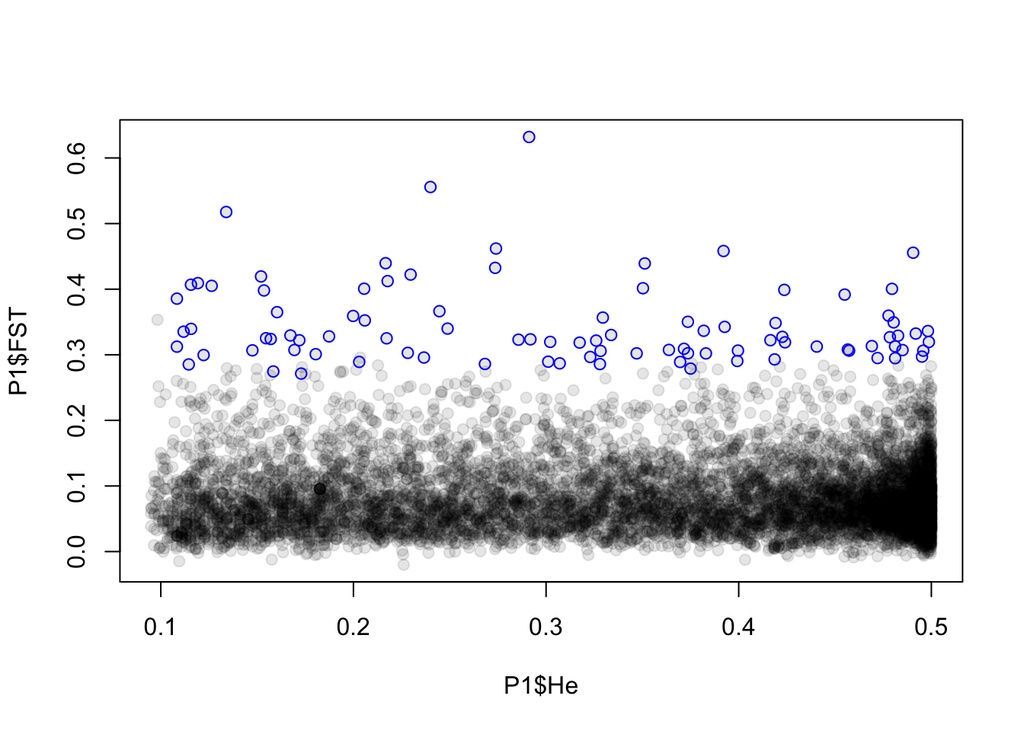

```r
# notice how the output is ordered differently
my_out <- P1$OutlierFlag==TRUE
plot(P1$He, P1$FST, pch=19, col=rgb(0,0,0,0.1))
points(P1$He[my_out], P1$FST[my_out], col="blue")
```

```r
# check the P-value histogram for the full set of data
# if there are outliers, it should look flat with an inflation near 0
```

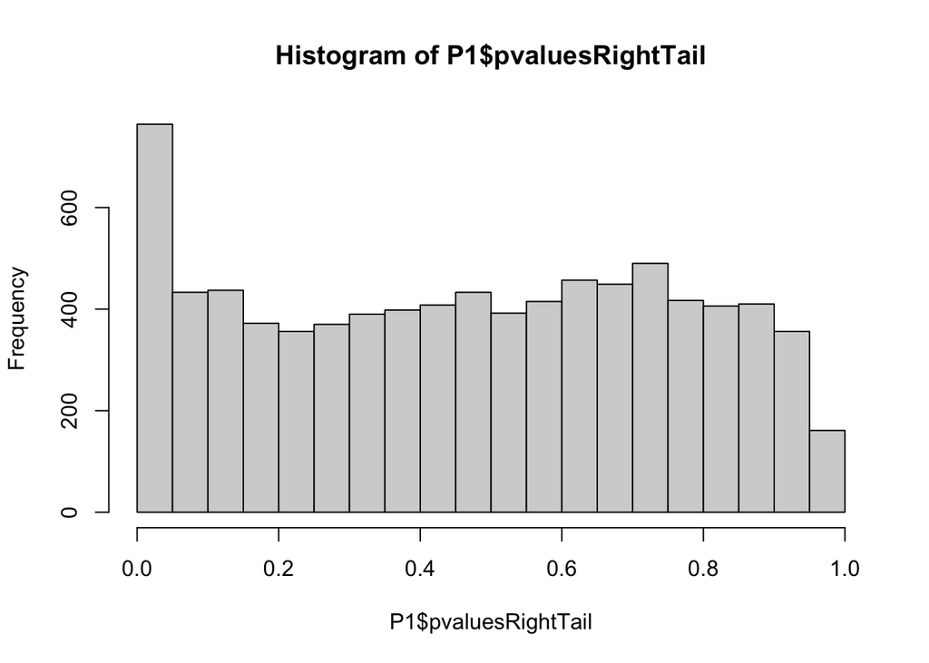

```r
hist(P1$pvaluesRightTail)
```

Highlight outliers on Manhattan Plot

For publication, we want to show the accurate estimate of FST, not the uncorrected estimate. Remember to exclude those low H loci!

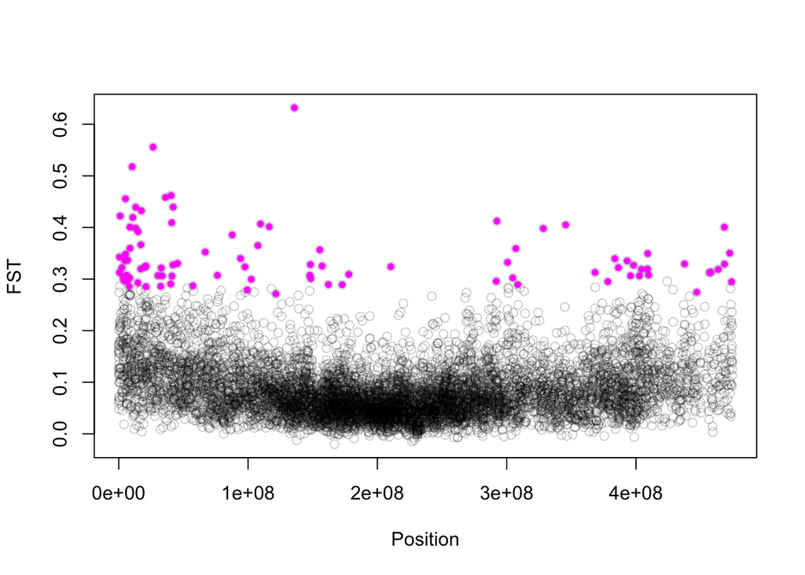

```r
# Use the separate() function to split the LocusName column
P1 <- P1 |>
  separate(LocusName, into = c("SNP_id", "LocusName"), sep = "\\.")

# Create plot
plot(P1$LocusName[P1$He>0.1], P1$FST[P1$He>0.1],
     xlab="Position", ylab="FST", col=rgb(0,0,0,0.2))
  points(P1$LocusName[my_out], P1$FST[my_out], col="magenta", pch=20)
```

```r
#   ____________________________________________________________________________
#   import the bim file with the SNP data                                   ####
snps <-
  read_delim(                    # to learn about the options use here, run ?read_delim on the console.
    here(
      "output","local_adaptation","outflank","brazil.bim"
    ),                           # use library here to load it
    col_names      = FALSE,      # we don't have header in the input file
    show_col_types = FALSE,      # suppress message from read_delim
    col_types      = "ccidcc"    # set the class of each column
  )
#
# set column names
colnames(
  snps
) <-                             # to add a header in our tibble
  c(
    "Scaffold", "SNP", "Cm", "Position", "Allele1", "Allele2"
  )
#
# check the tibble
head(snps)
```

```
## # A tibble: 6 × 6
##   Scaffold SNP            Cm Position Allele1 Allele2
##   <chr>    <chr>       <int>    <dbl> <chr>   <chr>
## 1 1        AX-93255729     0    39205 A       C
## 2 1        AX-93255723     0    61265 C       T
## 3 1        AX-93255722     0   104497 A       T
## 4 1        AX-93255719     0   122889 A       T
## 5 1        AX-93255712     0   179618 G       A
## 6 1        AX-93255711     0   183444 C       T
```

```r
# Use the separate() function to split the LocusName column
my_fst4 <- my_fst4 |>
  separate(LocusName, into = c("SNP_id", "LocusName"), sep = "\\.")

# Merge the data frames
merged_df <- merge(my_fst4, snps, by.x = "SNP_id", by.y = "SNP")

# Rename the column
merged_df <- rename(merged_df, Chromosome = Scaffold)

# View the first few rows of the merged data frame
head(merged_df)
```

```
##        SNP_id LocusName        He        FST          T1        T2  FSTNoCorr
## 1 AX-93213918 242643229 0.2489741 0.03378838 0.004215667 0.1247668 0.07538574
## 2 AX-93213924 184465554 0.4009696 0.02822752 0.005672154 0.2009441 0.07701419
## 3 AX-93213930 106521244 0.4309265 0.09670724 0.020932786 0.2164552 0.14811410
## 4 AX-93213933 106394391 0.4126934 0.10780850 0.022355845 0.2073662 0.15924031
## 5 AX-93213935 106338801 0.4999678 0.05174743 0.012973728 0.2507125 0.09750672
## 6 AX-93213950 106130702 0.3638322 0.12014727 0.021964166 0.1828104 0.16269272
##     T1NoCorr  T2NoCorr meanAlleleFreq Chromosome Cm  Position Allele1 Allele2
## 1 0.00940594 0.1247708      0.8542781          1  0 242643229       G       T
## 2 0.01547615 0.2009519      0.7225201          2  0 184465554       G       A
## 3 0.03206410 0.2164825      0.6858407          3  0 106521244       T       C
## 4 0.03302490 0.2073903      0.7089337          3  0 106394391       A       G
## 5 0.02444703 0.2507215      0.4959893          3  0 106338801       C       A
## 6 0.02974308 0.1828175      0.7609290          3  0 106130702       T       G
```

Use ggplot to make a new plot

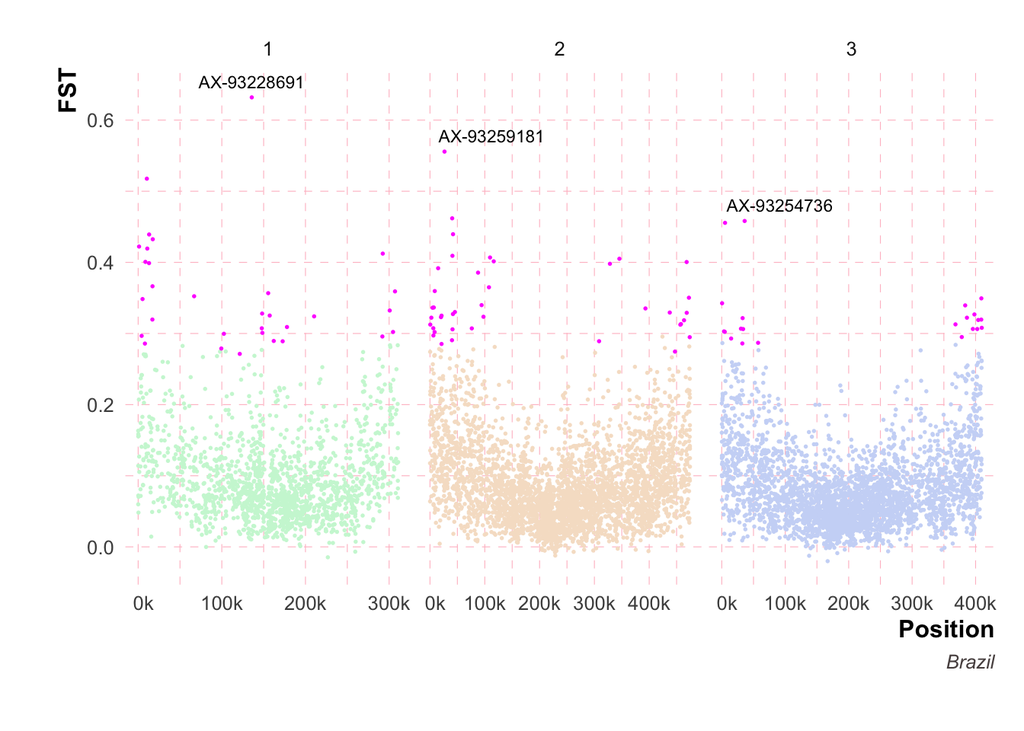

```r
# Subset dataframe for He > 0.1
df_sub <- subset(merged_df, He > 0.1)

# Adjust my_out condition to fit merged_df
my_out <- P1$SNP_id[P1$OutlierFlag == TRUE]

# Save it
write.table(
  my_out,
  file = here("output", "local_adaptation", "outflank","brazil_SNPs_outFlank.txt"),
  row.names = FALSE,
  quote = FALSE,
  col.names = FALSE,
  sep = "\n"
)

# Create a new column in the dataframe to define highlight points based on my_out
df_sub$highlight <- ifelse(df_sub$SNP_id %in% my_out, TRUE, FALSE)

# source the plotting function
source(
  here(
    "scripts", "analysis", "my_theme2.R"
  )
)

# Custom label function
k_format <- function(x) {
  paste0(format(x / 1e6, big.mark = "", scientific = FALSE), "k")
}

# Set colors for the chromosomes
color_vector <- c("#CCF6D6", "#F6E1CC", "#CCD8F6")  # Add or remove colors as needed.
names(color_vector) <- unique(df_sub$Chromosome)  # Make sure unique(df_sub$Chromosome) gives all unique Chromosome values.

# Filter data to include only the highest FST value for each chromosome
highest_FST <- df_sub[which(df_sub$highlight == TRUE), ]
highest_FST <- highest_FST[which(highest_FST$FST == ave(highest_FST$FST, highest_FST$Chromosome, FUN = max)), ]

# Create the plot
ggplot(df_sub, aes(x = Position, y = FST)) +
  geom_point(aes(color = Chromosome),
             data = subset(df_sub, highlight == FALSE),
             size = .3) +
  geom_point(
    color = "magenta",
    data = subset(df_sub, highlight == TRUE),
    size = .3
  ) +
  scale_color_manual(values = color_vector, guide = "none") +
  labs(x = "Position", y = "FST", caption = "Brazil") +
  facet_wrap(~ Chromosome, scales = "free_x") +
  scale_x_continuous(labels = k_format) +
  my_theme() +
  theme(panel.spacing = unit(.2, "lines"),
        plot.margin = unit(c(1, 1, 2, 2), "lines"),
        plot.caption = element_markdown(face = "italic", color = "#574E4E")) +
  # Annotate only the highest highlighted point for each chromosome
  geom_text_repel(
    data = highest_FST,
    aes(label = SNP_id),
    size = 3,
    nudge_y = 0.01,
    segment.color = NA,
    max.overlaps = Inf # Set to 'Inf' to show all annotations
  )
```

```r
# Save the plot
ggsave(
  here(
    "output", "local_adaptation", "figures", "outFlank_outliers_brazil.pdf"
  ),
  width  = 8,
  height = 5,
  units  = "in"
)
```